# Lecture 13

Sean Fahey

2023-04-05

```r
library(ggplot2)
library(Hotelling) # for hotelling's test
library(car)
library(mvnTest)
library(vegan)
```

# In Class

### bottle and iris datasets

univariate: one response multivariate: more than one response variable

- multiple measurements from the same individual that are **NOT independent**
- can be cont. or cat.
- will use multivariate for final

```r
data(bottle.df)
summary(bottle.df)
```

```
##      Number          Mn              Ba              Sr              Zr
##  Min.   :1.0   Min.   :41.80   Min.   :119.4   Min.   :112.4   Min.   : 50.00
##  1st Qu.:2.0   1st Qu.:54.98   1st Qu.:165.9   1st Qu.:146.5   1st Qu.: 75.38
##  Median :3.5   Median :58.65   Median :179.7   Median :164.7   Median : 83.55
##  Mean   :3.5   Mean   :58.20   Mean   :175.6   Mean   :159.2   Mean   : 84.02
##  3rd Qu.:5.0   3rd Qu.:63.08   3rd Qu.:191.1   3rd Qu.:170.7   3rd Qu.: 93.33
##  Max.   :6.0   Max.   :67.90   Max.   :209.8   Max.   :184.8   Max.   :125.70
##        Ti
##  Min.   :249.9
##  1st Qu.:275.2
##  Median :290.8
##  Mean   :291.2
##  3rd Qu.:306.2
##  Max.   :345.5
```

```r
cat('\n\n')
```

```r
# get just rows that match bottle 1 & 2
bottle.1 = bottle.df[bottle.df$Number == 1, -1] # leaving off the first column
bottle.2 = bottle.df[bottle.df$Number == 2, -1]

# get means for each column (for each bottle)
colMeans(bottle.1)
```

```
##      Mn      Ba      Sr      Zr      Ti
##  57.420 181.920 155.820  77.885 277.695
```

```r
colMeans(bottle.2)
```

```
##     Mn     Ba     Sr     Zr     Ti
##  59.15 183.31 162.68  82.31 289.24
```

```r
bottle_hotelling_test = hotelling.test(
                            x = bottle.1,
                            y = bottle.2
                          )

bottle_hotelling_test
```

```
## Test stat:  25.17
## Numerator df:  5
## Denominator df:  34
## P-value:  0.002949
```

p-value of 0.002949. Pretty low. Reject the null hypothesis that the elements in these bottle types is the same.

Use *MANOVA* to compare 2 or more multivariate samples. Like ANOVA, but for multivariate.

- Compares centers of each group. Each group is a cloud of points on n-dimensions (number of response variables).
- MANOVA only cares about center of the group cloud, like how ANOVA cares about the mean for each group’s response.

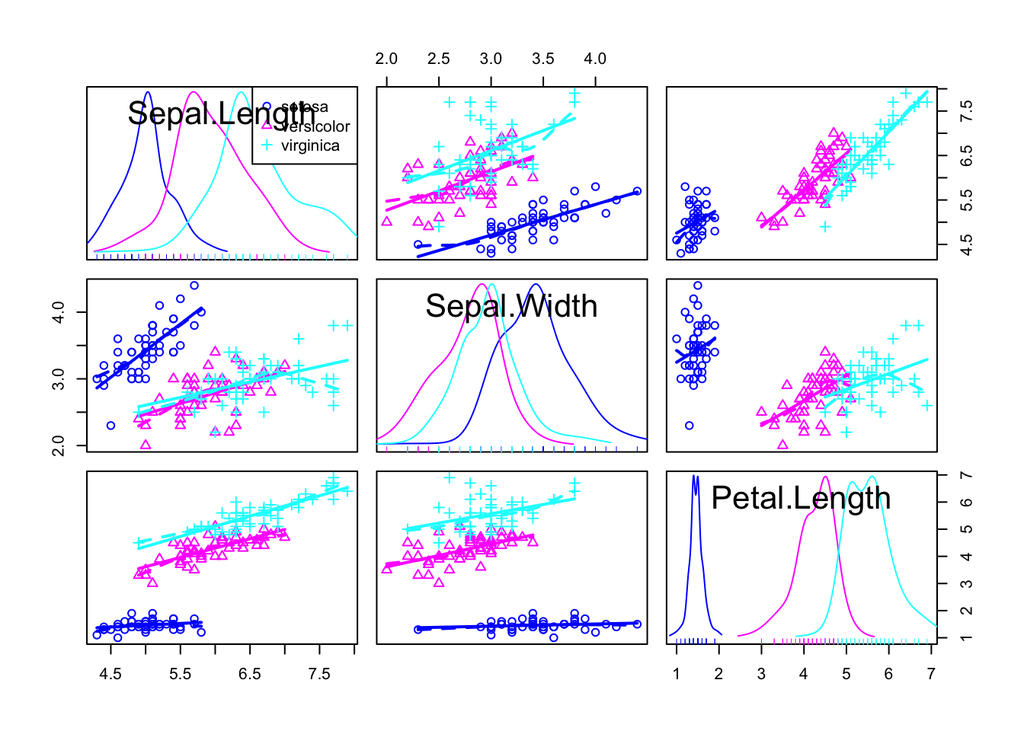

```r
scatterplotMatrix( # from car package
  ~ Sepal.Length +
    Sepal.Width +
    Petal.Length
  | Species,
  data=iris
  )
```

Another way to visualize is to just make boxplots for each response for each species.

```r
# using 2 response varaibles to start
manova.1 = manova(
  cbind(Sepal.Length, Sepal.Width) ~ # cbind because we need to do it on both
    Species,
  data=iris
  )

summary(manova.1)
```

```
##            Df  Pillai approx F num Df den Df    Pr(>F)
## Species     2 0.94531   65.878      4    294 < 2.2e-16 ***
## Residuals 147
## ---
## Signif. codes:  0 '***' 0.001 '**' 0.01 '*' 0.05 '.' 0.1 ' ' 1
```

```r
cat('\n\n\n')
```

```r
summary.aov(manova.1) # gives p value for each response variable
```

```
##  Response Sepal.Length :
##              Df Sum Sq Mean Sq F value    Pr(>F)
## Species       2 63.212  31.606  119.26 < 2.2e-16 ***
## Residuals   147 38.956   0.265
## ---
## Signif. codes:  0 '***' 0.001 '**' 0.01 '*' 0.05 '.' 0.1 ' ' 1
##
##  Response Sepal.Width :
##              Df Sum Sq Mean Sq F value    Pr(>F)
## Species       2 11.345  5.6725   49.16 < 2.2e-16 ***
## Residuals   147 16.962  0.1154
## ---
## Signif. codes:  0 '***' 0.001 '**' 0.01 '*' 0.05 '.' 0.1 ' ' 1
```

Looks like there’s a significant difference between the three species with respect to the size and shape of the sepal.

Also from the summary.aov, it looks like both response variables matter.

```r
manova.2 = manova(
  cbind(Sepal.Length, Sepal.Width, Petal.Length, Petal.Width) ~
    Species,
  data=iris
  )

summary(manova.2)
```

```
##            Df Pillai approx F num Df den Df    Pr(>F)
## Species     2 1.1919   53.466      8    290 < 2.2e-16 ***
## Residuals 147
## ---
## Signif. codes:  0 '***' 0.001 '**' 0.01 '*' 0.05 '.' 0.1 ' ' 1
```

```r
cat('\n\n\n')
```

```r
summary.aov(manova.2)
```

```
##  Response Sepal.Length :
##              Df Sum Sq Mean Sq F value    Pr(>F)
## Species       2 63.212  31.606  119.26 < 2.2e-16 ***
## Residuals   147 38.956   0.265
## ---
## Signif. codes:  0 '***' 0.001 '**' 0.01 '*' 0.05 '.' 0.1 ' ' 1
##
##  Response Sepal.Width :
##              Df Sum Sq Mean Sq F value    Pr(>F)
## Species       2 11.345  5.6725   49.16 < 2.2e-16 ***
## Residuals   147 16.962  0.1154
## ---
## Signif. codes:  0 '***' 0.001 '**' 0.01 '*' 0.05 '.' 0.1 ' ' 1
##
##  Response Petal.Length :
##              Df Sum Sq Mean Sq F value    Pr(>F)
## Species       2 437.10 218.551  1180.2 < 2.2e-16 ***
## Residuals   147  27.22   0.185
## ---
## Signif. codes:  0 '***' 0.001 '**' 0.01 '*' 0.05 '.' 0.1 ' ' 1
##
##  Response Petal.Width :
##              Df Sum Sq Mean Sq F value    Pr(>F)
## Species       2 80.413  40.207  960.01 < 2.2e-16 ***
## Residuals   147  6.157   0.042
## ---
## Signif. codes:  0 '***' 0.001 '**' 0.01 '*' 0.05 '.' 0.1 ' ' 1
```

All 4 response variables contribute to the difference.

### root dataset

```r
root = read.csv("root.txt", sep=' ', header=TRUE)
root$Tree.Number = as.factor(root$Tree.Number)

head(root)
```

```
##   Tree.Number Girth.4.Yr Ext.Growth.4.Yr Girth.15.Yr Weight.15.Yr
## 1           1       1.11           2.569        3.58        0.760
## 2           1       1.19           2.928        3.75        0.821
## 3           1       1.09           2.865        3.93        0.928
## 4           1       1.25           3.844        3.94        1.009
## 5           1       1.11           3.027        3.60        0.766
## 6           1       1.08           2.336        3.51        0.726
```

```r
manova.root = manova(
  cbind(Girth.4.Yr, Ext.Growth.4.Yr, Girth.15.Yr, Weight.15.Yr) ~
    Tree.Number,
  data=root
  )

summary(manova.root)
```

```
##             Df Pillai approx F num Df den Df    Pr(>F)
## Tree.Number  5 1.3055   4.0697     20    168 1.983e-07 ***
## Residuals   42
## ---
## Signif. codes:  0 '***' 0.001 '**' 0.01 '*' 0.05 '.' 0.1 ' ' 1
```

Looks like there is a significant difference between root stocks

```r
summary.aov(manova.root)
```

```
##  Response Girth.4.Yr :
##             Df  Sum Sq   Mean Sq F value Pr(>F)
## Tree.Number  5 0.07356 0.0147121   1.931 0.1094
## Residuals   42 0.31999 0.0076187
##
##  Response Ext.Growth.4.Yr :
##             Df  Sum Sq Mean Sq F value Pr(>F)
## Tree.Number  5  4.1997 0.83993  2.9052 0.0243 *
## Residuals   42 12.1428 0.28911
## ---
## Signif. codes:  0 '***' 0.001 '**' 0.01 '*' 0.05 '.' 0.1 ' ' 1
##
##  Response Girth.15.Yr :
##             Df Sum Sq Mean Sq F value    Pr(>F)
## Tree.Number  5 6.1139 1.22279  11.969 3.112e-07 ***
## Residuals   42 4.2908 0.10216
## ---
## Signif. codes:  0 '***' 0.001 '**' 0.01 '*' 0.05 '.' 0.1 ' ' 1
##
##  Response Weight.15.Yr :
##             Df Sum Sq Mean Sq F value    Pr(>F)
## Tree.Number  5 2.4931 0.49862  12.158 2.587e-07 ***
## Residuals   42 1.7225 0.04101
## ---
## Signif. codes:  0 '***' 0.001 '**' 0.01 '*' 0.05 '.' 0.1 ' ' 1
```

Girth and weight at 15 years are the most important responses.

*Some assumptions MANOVA makes:*

1. Samples are random. ie. root stocks aren’t close or far from each other, in more sunlight, etc.
2. Normally distributed errors for each response, and equal variances among groups
   - This can be tested with ANOVA, t-test, etc.
3. Errors (residuals) follow a multivariate normal distribution
   - mvnTest is a package that tests for this
4. Co-variances are equal among groups

```r
DH.test(data = iris[iris$Species=='versicolor',1:4])
```

```
##             Doornik-Hansen test for Multivariate Normality
##
##   data : iris[iris$Species == "versicolor", 1:4]
##
##   DH              : 14.63946
##   p-value         : 0.06654683
##
##   Result  : Data are multivariate normal (sig.level = 0.05)
```

**What if you can’t meet the assumptions required for MANOVA?**

Use **ANOSIM** to figure out if you have a problem. (Analysis of Similarity): anosim()

*OR*

Use **PERMANOVA** (non-parametric anova): adonis2()

### darlingtonia dataset

Goal is to quantify how far apart two samples are in euclidean space.

```r
darl = read.csv("DarlingtoniaData.csv", header=TRUE)
head(darl)
```

```
##   Site height mouth_diam tube_diam keel_diam wing1_length wing2_length
## 1  TJH    654       38.4      16.6       6.4           85           76
## 2  TJH    413       22.2      17.2       5.9           55           26
## 3  TJH    610       31.2      19.9       6.7           62           60
## 4  TJH    546       34.4      20.8       6.3           84           79
## 5  TJH    665       30.5      20.4       6.6           60           51
## 6  TJH    665       33.6      19.5       6.6           84           66
##   wingsprea hoodarea wingarea tubearea hoodmass_g tubemass_g wingmass_g Ca_ppm
## 1        55    63.77    33.65    87.15       1.38       3.54       0.29 717.90
## 2        60    21.10     7.36    44.78       0.49       1.48       0.06 392.74
## 3        78    28.47    15.75    56.64       0.60       2.20       0.16 402.45
## 4        95    48.82    30.47    76.31       1.12       2.95       0.24 497.16
## 5        30    29.48    11.33   100.22       0.67       3.36       0.08 504.48
## 6        82    55.67    27.54   106.12       1.27       4.05       0.21 435.90
##     P_ppm    K_ppm  Mg_ppm C_pct H_pct N_pct
## 1  997.12 10699.50 1983.40 49.43  5.50  0.93
## 2  876.99  9576.49 1540.73 50.24  5.63  0.94
## 3 1287.62 11738.73 1514.21 50.77  5.58  1.08
## 4  662.55 11173.37 1399.24 50.27  5.67  0.88
## 5 1115.53  7017.39 1964.15 50.20  5.56  0.98
## 6 1344.98  8322.84 2618.65 49.61  5.76  1.38
```

height is very large, but the other values are very small. Time to standardize the data.

```r
height = scale(darl$height, center=TRUE, scale=TRUE)
mouth_diam = scale(darl$mouth_diam, center=TRUE, scale=TRUE)
tube_diam = scale(darl$tube_diam, center=TRUE, scale=TRUE)
```